# Analysis of in-house generated GpC methylation (PEPC) vs commercial (NEB) enzymes

Kasit Chatsirisupachai

2024-06-21

# Introduction

This notebook shows standard quality control steps to test GpC methyltransferase enzyme activity of PEPC enzyme, comparing with the reference (NEB enzyme).

## Data

*Drosophila* S2 cells were treated with different concentration of the in-house generated GpC methyltransferase enzyme (24 units, 32 units, and 40 units) and NEB enzyme as a reference. All conditions were generated in duplicates. SMF library were sequenced using Illumina NextSeq platform.

Once obtain the raw sequencing data, Fastq files were aligned to the *Drosophila* dm6 genome using `QuasR` package. Duplicate reads were removed using `Picard` and `Samtools`. Then, BAM files from replicates of the same treatment condition were merged.

In this example, we subset the BAM files to contain only reads from `chr4` only.

# PEPC vs NEB Enzyme Efficiency

## Load libraries

```r
library(QuasR)
library(SingleMoleculeFootprinting)
library(BSgenome.Dmelanogaster.UCSC.dm6)
library(tidyverse)
```

```r
library(ggplot2)
library(GGally)
library(here)
```

## Create QuasR input file

We will first create QuasR input file, which will be used by QuasR package to locate the BAM files and sample name. QuasR input file contains two columns: 1) BAM file names, and 2) sample names. All BAM files for this example are in the folder `/data/dataset_2_S2_PEPCvsNEB`

```r
Qinput <- "/g/krebs/chatsiri/SMF_tutorial/analysis/example_2/Qinput_PEPC_batch7_chr4.txt"
```

## 1. Cytosine conversion rate

Here, we will quantify the cytosine conversion rate of each sample, by asking how much of the observed cytosine methylation falls into the expected context (GpC in this case).

Please note that this example only contain data from one chromosome. But in an actual full data set, we can simply write a loop over chromosomes to measure cytosine conversion rates.

```r
chr_ConversionRate <- ConversionRate(sampleSheet = Qinput,
                                     genome = BSgenome.Dmelanogaster.UCSC.dm6,
                                     chr = "chr4",
                                     cores = 4)
```

```
## all necessary alignment files found
```

```
## preparing to run on 4 nodes...done
```

```r
print(chr_ConversionRate)
```

```
## s1_Batch7_24_NO_chr4_M s2_Batch7_32_NO_chr4_M s3_Batch7_40_NO_chr4_M
##                   98.8                   98.9                   98.8
##       s4_NEB_NO_chr4_M
##                   98.4
```

Now we can plot the conversion rate using bar plot.

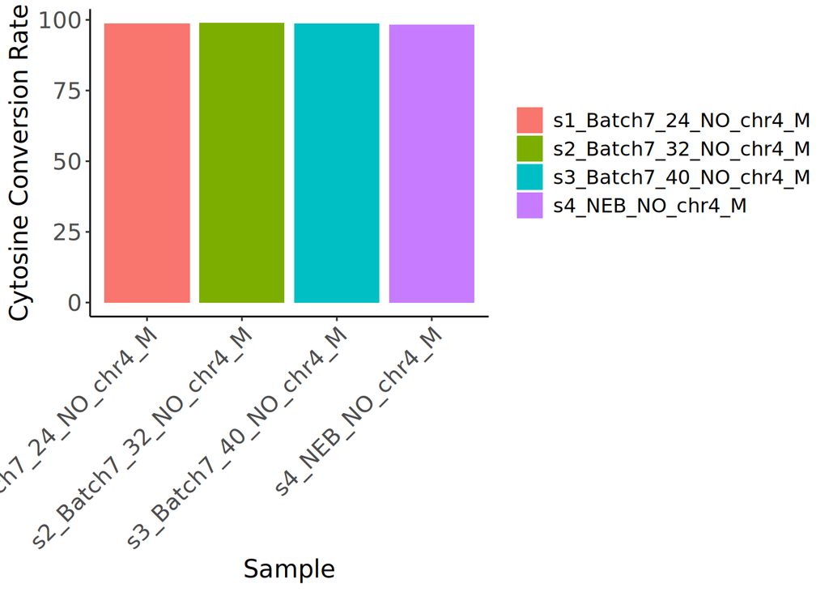

```r
# plotting
chr_ConversionRate %>%
  as.data.frame() %>%
  rownames_to_column(var = "sample") %>%
  as.tibble() %>%
  rename(ConversionRate = 2) -> plot_df

plot_df %>% ggplot(aes(x = sample, y = ConversionRate, fill = sample)) +
  geom_bar(stat="identity") +
  xlab("Sample") +
  ylab("Cytosine Conversion Rate") +
  theme(axis.text.x = element_text(size = 14, angle = 45, hjust = 1, vjust = 1),
        axis.text.y = element_text(size = 14),
        axis.title.x = element_text(size=15),
        axis.title.y = element_text(size=15),
        legend.title = element_blank(),
        legend.text = element_text(size = 12),
        legend.position = "right",
        panel.background = element_blank(),
        axis.line = element_line(colour = "black"))
```

What actually happened under the hood of the function `ConversionRate`?

```r
# unpack the steps in the ConversionRate function
ConversionRate
```

```
## function (sampleSheet, genome, paired = "fr", chr = 19, cores = 1)
## {
##     QuasRprj = GetQuasRprj(sampleSheet, genome, paired)
##     seq_length = seqlengths(genome)
##     chr = tileGenome(seq_length[chr], tilewidth = max(seq_length[chr]),
##         cut.last.tile.in.chrom = TRUE)
##     cl = makeCluster(cores)
##     methylation_calls_C = qMeth(QuasRprj, query = chr, mode = "allC",
##         reportLevel = "C", keepZero = TRUE, clObj = cl, asGRanges = TRUE,
##         collapseBySample = FALSE)
##     stopCluster(cl)
##     seqContext = getSeq(genome, trim(resize(methylation_calls_C,
##         3, fix = "center")))
##     GCc = vcountPattern(DNAString("GCN"), seqContext, fixed = FALSE)
##     CGc = vcountPattern(DNAString("NCG"), seqContext, fixed = FALSE)
##     out_c_met = methylation_calls_C[GCc == 0 & CGc == 0, ]
##     tot.col = grep("_T$", colnames(values(out_c_met)))
##     met.col = grep("_M$", colnames(values(out_c_met)))
##     tot.c = as.matrix(values(out_c_met)[, tot.col])
##     met.c = as.matrix(values(out_c_met)[, met.col])
##     conv_rate = round((1 - (colSums(met.c)/colSums(tot.c))) *
##         100, 1)
##     return(conv_rate)
## }
## <bytecode: 0x56c7ba8>
## <environment: namespace:SingleMoleculeFootprinting>
```

## 2. Correlation of cytosine methylation rate between samples

Now, we can compare methylation rate across samples. We will identify the methylation status for the Cytosines in the genomic context relevant for the experiment (Single enzyme, double enzyme, etc.). The type of the experiment is inferred based on which user-provided substring is found in the SampleName field of the QuasR input file:

### Call context methylation

```r
#Qinput <- paste0(here::here(), "/analysis/example_2/Qinput_PEPC_batch7_chr4.txt")
MySample <- suppressMessages(readr::read_delim(Qinput, delim = "\t")[[2]])

genome <- BSgenome.Dmelanogaster.UCSC.dm6

# make cluster
cluObj <- makeForkCluster(nnodes = 4)

# region of interest (in this example we only have chromosome 4)
# chromosome 4 is the fifth on the Dmelanogaster genome (chr2L, chr2R, chr3L, chr3R, chr4)
gr <- GRanges(seqnames = seqnames(Dmelanogaster)[5],
              ranges = IRanges(start = 1, end = seqlengths(Dmelanogaster)[5]),
              strand = "*")

print(gr)
```

```
## GRanges object with 1 range and 0 metadata columns:
##       seqnames    ranges strand
##          <Rle> <IRanges>  <Rle>
##   [1]     chr4 1-1348131      *
##   -------
##   seqinfo: 1 sequence from an unspecified genome; no seqlengths
```

```r
# Call context methylation
Context_Methylation <- CallContextMethylation(sampleSheet = Qinput,
                                              sample = MySample,
                                              genome = genome,
                                              RegionOfInterest = gr,
                                              returnSM = FALSE,
                                              coverage = 20,
                                              ConvRate.thr = 0.2,
                                              clObj = cluObj)
```

```
## Setting QuasR project
```

```
## all necessary alignment files found
```

```
## Calling methylation at all Cytosines
```

```
## preparing to run on 4 nodes...done
## checking if RegionOfInterest contains information at all
## Discard immediately the cytosines not covered in any sample
## Subsetting Cytosines by permissive genomic context (GC, HCG)
## Collapsing strands
## Filtering Cs for coverage
## Detected experiment type: NO
## Subsetting Cytosines by strict genomic context (DGCHN, -, NWCGW) based on the detected experiment type: NO
## Returning non merged matrixes
```

The Context_Methylation object contain, for each sample, an average methylation level at each cytosine in GC and CG contexts.

```r
# GC context
Context_Methylation$DGCHN %>% head() %>% print()
```

```
## GRanges object with 6 ranges and 9 metadata columns:
##       seqnames    ranges strand | Batch7_24_NO_chr4_Coverage
##          <Rle> <IRanges>  <Rle> |                  <integer>
##   [1]     chr4       445      + |                         37
##   [2]     chr4       499      + |                         26
##   [3]     chr4       507      + |                         28
##   [4]     chr4       627      + |                         34
##   [5]     chr4       665      + |                       <NA>
##   [6]     chr4       757      + |                         31
##       Batch7_24_NO_chr4_MethRate Batch7_32_NO_chr4_Coverage
##                        <numeric>                  <integer>
##   [1]                  0.1621622                         44
##   [2]                  0.1538462                         39
##   [3]                  0.1071429                         38
##   [4]                  0.1176471                         38
##   [5]                         NA                       <NA>
##   [6]                  0.0967742                         57
##       Batch7_32_NO_chr4_MethRate Batch7_40_NO_chr4_Coverage
##                        <numeric>                  <integer>
##   [1]                   0.159091                         62
##   [2]                   0.153846                         48
##   [3]                   0.105263                         51
##   [4]                   0.210526                         49
##   [5]                         NA                         29
##   [6]                   0.105263                         60
##       Batch7_40_NO_chr4_MethRate NEB_NO_chr4_Coverage NEB_NO_chr4_MethRate
##                        <numeric>            <integer>            <numeric>
##   [1]                   0.209677                   41             0.121951
##   [2]                   0.312500                   34             0.294118
##   [3]                   0.196078                   30             0.233333
##   [4]                   0.204082                   26             0.307692
##   [5]                   0.103448                 <NA>                   NA
##   [6]                   0.166667                   35             0.171429
##       GenomicContext
##          <character>
##   [1]          DGCHN
##   [2]          DGCHN
##   [3]          DGCHN
##   [4]          DGCHN
##   [5]          DGCHN
##   [6]          DGCHN
##   -------
##   seqinfo: 1870 sequences (1 circular) from dm6 genome
```

```r
# CG context
Context_Methylation$NWCGW %>% head() %>% print()
```

```
## GRanges object with 6 ranges and 9 metadata columns:
##       seqnames    ranges strand | Batch7_24_NO_chr4_Coverage
##          <Rle> <IRanges>  <Rle> |                  <integer>
##   [1]     chr4       474      + |                         33
##   [2]     chr4       495      + |                         24
##   [3]     chr4       583      + |                         39
##   [4]     chr4       602      + |                         36
##   [5]     chr4       733      + |                       <NA>
##   [6]     chr4       784      + |                         53
##       Batch7_24_NO_chr4_MethRate Batch7_32_NO_chr4_Coverage
##                        <numeric>                  <integer>
##   [1]                  0.0303030                         38
##   [2]                  0.0000000                         40
##   [3]                  0.0000000                         48
##   [4]                  0.0000000                         44
##   [5]                         NA                         27
##   [6]                  0.0188679                         91
##       Batch7_32_NO_chr4_MethRate Batch7_40_NO_chr4_Coverage
##                        <numeric>                  <integer>
##   [1]                   0.000000                         51
##   [2]                   0.000000                         48
##   [3]                   0.000000                         67
##   [4]                   0.000000                         60
##   [5]                   0.000000                         26
##   [6]                   0.010989                         98
##       Batch7_40_NO_chr4_MethRate NEB_NO_chr4_Coverage NEB_NO_chr4_MethRate
##                        <numeric>            <integer>            <numeric>
##   [1]                  0.0000000                   39            0.0256410
##   [2]                  0.0000000                   34            0.0294118
##   [3]                  0.0149254                   36            0.0000000
##   [4]                  0.0000000                   32            0.0000000
##   [5]                  0.0000000                 <NA>                   NA
##   [6]                  0.0102041                   66            0.0151515
##       GenomicContext
##          <character>
##   [1]          NWCGW
##   [2]          NWCGW
##   [3]          NWCGW
##   [4]          NWCGW
##   [5]          NWCGW
##   [6]          NWCGW
##   -------
##   seqinfo: 1870 sequences (1 circular) from dm6 genome
```

### Pair plot to see correlation of GC methylation level across samples.

#### helper functions for the plot

```r
jet.colors <- grDevices::colorRampPalette(c("#00007F", "blue", "#007FFF", "cyan","#7FFF7F", "yellow", "#FF7F00", "red", "#7F0000"))

panel.jet <- function(...) {
  smoothScatter(..., nrpoints=0, add=TRUE, colramp=jet.colors)
  }

panel.hist <- function(x, ...) {
  usr <- par("usr"); on.exit(par(usr))
  par(usr = c(usr[1:2], 0, 1.5) )
  h <- hist(x, plot = FALSE)
  breaks <- h$breaks; nB <- length(breaks)
  y <- h$counts; y <- y/max(y)
  rect(breaks[-nB], 0, breaks[-1], y, col="grey", ...)
  }

panel.cor <- function(x, y, digits=2, prefix="", cex.cor, ...) {
  usr <- par("usr"); on.exit(par(usr))
  par(usr = c(0, 1, 0, 1))
  r <- abs(cor(x, y, use="pairwise.complete.obs"))
  txt <- format(c(r, 0.123456789), digits=digits)[1]
  txt <- paste(prefix, txt, sep="")
  if(missing(cex.cor)) cex.cor <- 2.5/strwidth(txt)
  text(0.5, 0.5, txt)
  }
```

#### Plot GC methylation

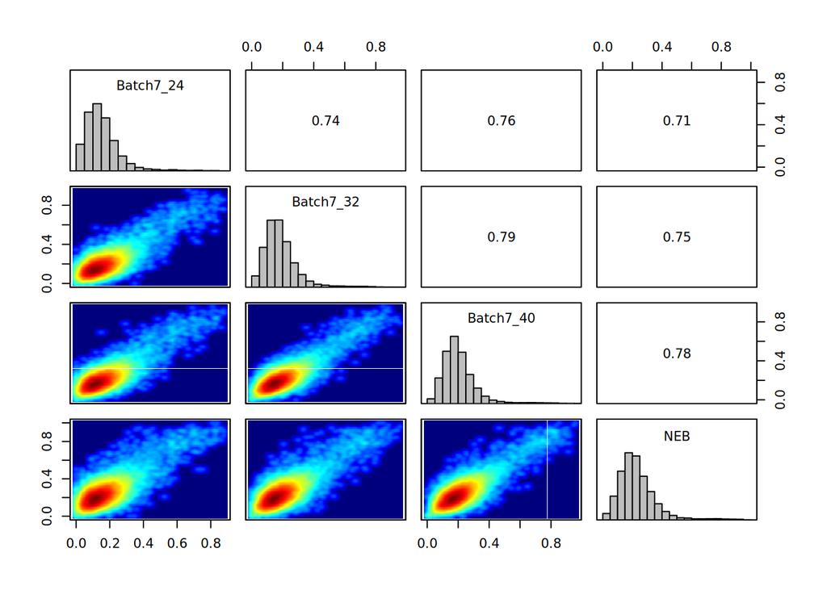

```r
Context_Methylation_DGCHN <- Context_Methylation$DGCHN
MethRate_df <- Context_Methylation_DGCHN %>%
    as.data.frame() %>%
    select(matches("MethRate"))

# remove NAs
MethRate_df <- MethRate_df[complete.cases(MethRate_df),]

# clean column names
colnames(MethRate_df) <- unlist(lapply(colnames(MethRate_df), gsub, pattern = "_NO_chr4_MethRate", replacement = ""))

# plot
p <- pairs(MethRate_df,
           upper.panel = panel.cor,
           diag.panel = panel.hist,
           lower.panel = panel.jet,
           cex.labels = 1)
```

From the histogram, we can see that the average methylation level increases as we increase the PEPC enzyme concentration (24, 32, 40 units). Furthermore, we can see decent correlation levels across samples. The correlation between PEPC enzyme-treated samples and NEB enzyme-treated samples increases following the PEPC enzyme concentration.

#### Plot CG methylation

As a comparison, we will plot the average methylation correlation across samples in the CG context. This we do not expect a correlation, as we did not make a CG enzyme treatment. Indeed, the situation will be different if we perform dual-enzyme treatment.

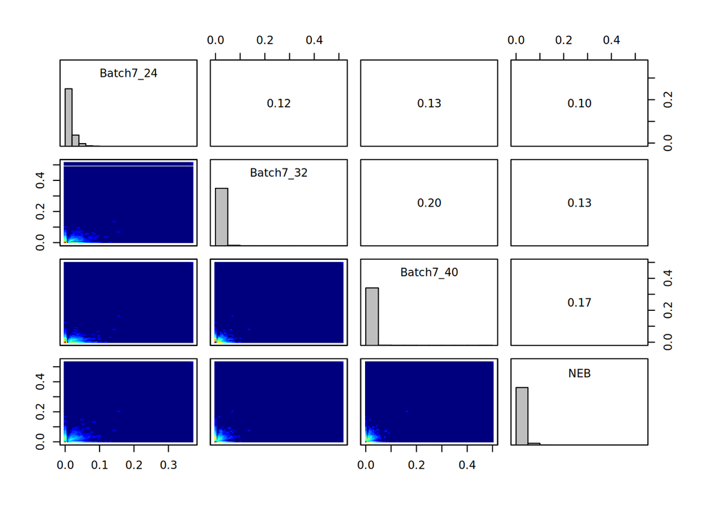

```r
Context_Methylation_NWCGW <- Context_Methylation$NWCGW
MethRate_df <- Context_Methylation_NWCGW %>%
    as.data.frame() %>%
    select(matches("MethRate"))

# remove NAs
MethRate_df <- MethRate_df[complete.cases(MethRate_df),]

# clean column names
colnames(MethRate_df) <- unlist(lapply(colnames(MethRate_df), gsub, pattern = "_NO_chr4_MethRate", replacement = ""))

# plot
p <- pairs(MethRate_df,
           upper.panel = panel.cor,
           diag.panel = panel.hist,
           lower.panel = panel.jet,
           cex.labels = 1)
```